# BIN210 innlevering uke 8: Sekvensmodeller

Par-gruppe 55: Katrine Weilin Fredheim & Ane Kleiven

2025-03-26

# Last inn nødvendige R-pakker

```r
library(stringr)
library(tidyverse)
library(microseq)
library(ggplot2)
```

# 1 Bruk av Artificial Intelligence (AI)

Chat-GPT-4-turbo er brukt til å assistere med koding underveis i oppgaven, spesielt for feilsøking ved error. I siste oppgave ble Chat-GPT brukt for å finne funksjonen `map_int()`, for å telle opp antall treff i listen. AI ble også brukt for å endre farger på stolpediagrammet.

Github Copilot har vært på underveis, og har kommet med forslag til kode.

# 2 Regulære uttrykk

```r
# et regulært uttrykk
CTHLGC
```

```r
# uttrykket modifisert første gang
CTH[LF]GC
```

**Hvor mange unike sekvenser kan matche dette?**

2 unike sekvenser kan matche dette, CTHLGC og CTHFGC.

```r
C[^ARNDCQEGHILKMNFWYV]H[LFI]GC
```

**Hvor mange unike sekvenser kan matche nå? Kan du formulere en regel for hvordan vi regner ut dette?**

Aminosyrer nummer 2 må være enten Serin, Threonin eller Prolin (alle de andre er ekskludert i parentesen). Aminosyre nummer 4 må være enten Leusin, Fenylalanin eller Isoleusin.

Dette gir 3 * 3 = 9 unike sekvenser, siden vi har 3 muligheter for aminosyre nummer 2 og 3 muligheter for aminosyre nummer 4.

En generell regel: Antall unike sekvenser = antall muligheter for aminosyre 1 * antall muligheter for aminosyre 2 * antall muligheter for aminosyre 3 * … * antall muligheter for aminosyre n.

Antall unike sekvenser er produktet av mulige aminosyrer i hver posisjon.

**Lag korteste mulige regulære uttrykk slik at følgende sekvens gir treff:**

```r
TGCTTTT
```

```r
TGCT{4}
```

**Bruk det regulære uttrykket fra over. Finn hvor mange treff det gir i følgende sekvens:**

```r
ATCTGCTTTTACCAAATGCTTTTGCTTTT
```

```r
str_extract_all("ATCTGCTTTTACCAAATGCTTTTGCTTTT", "(TGCT{4})")[[1]]
```

```
## [1] "TGCTTTT" "TGCTTTT"
```

Søket gir to treff av TGCTTTTT, men hvis vi ser på sekvensen er det i realiteten tre tilfeller av uttrykket - bare at tilfelle nummer to og tre overlapper.

# 3 Shine-Dalgarno: En myte?

```r
SD.pattern <- "AGGAGG"
SD.tbl <- readFasta("data/ecoli_upstream.fasta.txt") |>
  mutate(Has.SD = str_detect(Sequence, SD.pattern))
cat("Fant mønsteret i", sum(SD.tbl$Has.SD), "av totalt",
    nrow(SD.tbl), "sekvenser\n")
```

```
## Fant mønsteret i 112 av totalt 4146 sekvenser
```

**Hvor mange av oppstrøms-sekvensene inneholder motivet “AGGAGG”?**

112 av 4146 oppstrøms-sekvenser inneholder motivet “AGGAGG”.

```r
SD.pattern.2 <- "[AG][AG][AG][AG][AG][AG]"
SD.tbl.2 <- readFasta("data/ecoli_upstream.fasta.txt") |>
  mutate(Has.SD = str_detect(Sequence, SD.pattern.2))
cat("Fant mønsteret i", sum(SD.tbl.2$Has.SD), "av totalt",
    nrow(SD.tbl.2), "sekvenser\n")
```

```
## Fant mønsteret i 2162 av totalt 4146 sekvenser
```

**Hvor mange flere treff får du hvis du legger inn denne ’romsligheten?**

**Lag en liten tabell der den ene kolonnen angir mønsteret du brukte (innkludert “AGGAGG”) og i andre kolonne antall treff det ga.**

```r
data.frame(Pattern = c("AGGAGG", "[AG][AG][AG][AG][AG][AG]"),
           Positives = c(sum(SD.tbl$Has.SD), sum(SD.tbl.2$Has.SD)))
```

```
##                    Pattern Positives
## 1                   AGGAGG       112
## 2 [AG][AG][AG][AG][AG][AG]      2162
```

*Til slutt en frivillig nøtt: La oss vende tilbake til det opprinnelige motivet “AGGAGG”. Tenk deg at vi søkte med dette mot 4146 helt tilfeldig genererte sekvenser av lengde 25, altså sekvenser der alle 4 basene er trukket tilfeldig og med lik sannsynlighet (E. coli har GC-innhold på 50%). Hvor mange treff ville vi da forvente å få? På bakgrunn av dette, er Shine-Dalgarno sekvensen en myte? Hint: Tenk binomisk variabel.*

Sannsynlighet for A = 0.25 Sannsynlighet for G = 0.25 Sannsynlighet for C = 0.25 Sannsynlighet for T = 0.25

Sannsynlighet for AGGAGG = p = (1/4)^6 = 1/4096

En sekvens på 20 baser kan begynne på 20 ulike steder.

Totalt antall mulige plasseringer for sekvensen = n = 20 * 4146 = 82920

Forventet antall treff = n * p = 82920 * 1/4096 = 20

Ved beregning forventer vi ikke mer enn 20 Shine Dalgarno sekvenser, dette viser at sekvensen ikke oppstår ved tilfeldighet.

# 4 PSSM

```r
A  -2 -1 -2 -2 0
C   1 -1 -2 -2 0
G  -2 -3  1 -2 0
T  -2  1 -2  1 0
```

**Hva er den maksimale score en sekvens kan oppnå med denne, og hvilken sekvens oppnår dette?**

4 er den maksimale score en sekvens kan oppnå. Sekvensen som oppnår dette er CTGT[ACGT]

**Hva er nest høyeste score? Hvilken sekvens oppnår dette?**

Den nest høyeste scoren er 2, og sekvensen som oppnår dette er C[AC]GT[ACGT]

**Hva er forventet score for en tilfeldig sekvens der alle de fire basene forekommer med samme sannsynlighet?**

Forventet score posisjon 1 = 0.25 * (-2) + 0.25 * 1 + 0.25 * (-2) + 0.25 * (-2) = -1.25 Forventet score posisjon 2 = 0.25 * (-1) + 0.25 * (-1) + 0.25 * (-3) + 0.25 * 1 = -1 Forventet score posisjon 3 = 0.25 * (-2) + 0.25 * (-2) + 0.25 * 1 + 0.25 * (-2) = -1.25 Forventet score posisjon 4 = 0.25 * (-2) + 0.25 * (-2) + 0.25 * (-2) + 0.25 * 1 = -1.25

Forventet score = -1.25 - 1 - 1.25 - 1.25 = -4.75

**Hva er rart med denne modellen? Hvis noen foreslår en slik PSSM, så bør du komme med et kritisk innspill. Hvorfor?**

Alle verdier i posisjon 5 er 0, noe som betyr at det ikke spiller noen rolle hvilken base som er i posisjon 5. Dette er rart, fordi det er ingen grunn til at alle basene skal ha samme score i posisjon 5. Sannsynligvis vil en base være mer biologisk relevant enn en annen i en gitt posisjon.

I tillegg er det ganske høye straffer for å ha en base som ikke er forventet i en gitt posisjon.

# 5 Søk med PSI-BLAST

## 5.1 BLAST-søk mot PDB-proteiner

Vi har følgende proteinsekvens:

```r
MSSIGQSILMALTVTVNKYASLNVQAVHRREAKTPKTTGAKAKAAAAFQDIGRRGLLLSSVVAAPQVNND DSKTQLLQKYLKKSEENKAKNDKERMDSYYKRNYKDYFDFIEGSLKGKSEQELSESEKGILEWLKTNK
```

**Kjør søket som beskrevet over. Hvor mange treff får din sekvens hos PDB-proteinene?**

Søket gir ingen signifikante treff.

## 5.2 Vi lager en PSSM med PSI-BLAST

**Hvor mange treff får du i dette søket? Hvorfor ble det flere treff enn i forrige søk?**

Det nye søket ga 500+ treff (antall sekvenser satt til 500).

PDB-databasen inneholder kun proteiner med kjente strukturer, og er derfor en relativt liten og spesialisert database. Dersom sekvensen ikke har en nær strukturell homolog, vil den ikke gi treff i PDB.

nr-databasen (non-redundant protein sequence database) er en større database, som inneholder sekvensdata fra mange flere proteiner - inkludert teoretisk predikerte proteiner. Dette gjør at det er større sannsynlighet for at en sekvens vil gi treff i nr enn i PDB.

I det første søket brukte vi blastp, som gjør et enkelt sekvenssøk mot databasen, og kun finner proteiner med høy sekvenslikhet. I det andre søket brukte vi PSI-blast, som bruker en iterativ søkemetode. Første søk finner sekvenser som er nært beslektede. Deretter bygges en PSSM (posisjons-spesifikk vektingsmatrise), som brukes til å finne mer fjerne homologer i de neste iterasjonene.

Valg av database og bruk av PSI-blast gjør at vi får flere treff i det andre søket enn i det første.

## 5.3 Kjør nytt søk mot PDB

**Hvor mange treff får du nå? Skriv noen ord om hva som utgjør forskjellen i det første og siste søket. Prøv å følge lenker fra beste treff til PDB og et bilde av protein-strukturen. Legg dette inn i rapporten.**

Det nye søket ga 2 signifikante treff. I det første søket gjorde vi kun et enkelt blastp søk mot PDB, og fikk ingen treff. blastp søker eksakte eller nesten eksakte treff mellom query-sekvensen og sekvensene i databasen.

I det andre søket brukte vi PSI-blast, med en ferdig PSSM. PSSM’en gir hver posisjon i sekvensen ulike scoringsverdier, basert på hvor ofte en gitt aminosyre forekommer i den posisjonen i en gruppe av sekvenser. Dette gjør at vi kan finne mer fjerne homologer enn med et enkelt blastp-søk. PSSM vekter konserverte posisjoner sterkere, og varierende posisjoner svakere, og er derfor en mer sensitiv metode enn blastp.

Under er et bilde av PDB-strukturen. Proteinet som ble funnet er 5ZJI - ‘Chain N, Photosystem I reaction center subunit N’.

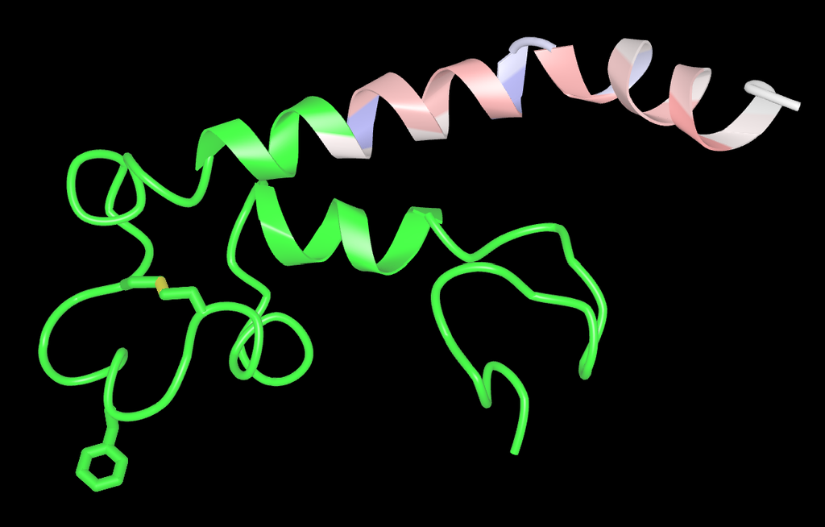

```r
knitr::include_graphics('data/proteinstructure_5ZJI_N.png')
```

# 6 R-lab

## 6.1 Regulære uttrykk i R

```r
# lær mer om regulære uttrykk i R
?regex
```

## 6.2 Søking med regulære uttrykk - `str_detect()` og `str_which()`

```r
sekvenser <- c("ATGCCTACGTTCGACT",
               "GTGCCTGCAATCG",
               "ATGCCTGCCCACAAACTG")
har.treff <- str_detect(sekvenser, "CCT")
print(har.treff)
```

```
## [1] TRUE TRUE TRUE
```

```r
index.treff <- str_which(sekvenser, "CCT")
print(index.treff)
```

```
## [1] 1 2 3
```

```r
har.treff <- str_detect(sekvenser, 'AA')
har.treff
```

```
## [1] FALSE  TRUE  TRUE
```

```r
index.treff <- str_which(sekvenser, 'AA')
index.treff
```

```
## [1] 2 3
```

```r
har.treff <- str_detect(sekvenser, "CC")
print(har.treff)
```

```
## [1] TRUE TRUE TRUE
```

## 6.3 Søking med `str_locate_all()`

```r
sekvens <- "CCTGCTTAACTGCTTGGCCCTACCTCACCGTCCACTGCCCTGGGGTCCCAAAAATCGTCGTCACAC"
treff.lst <- str_locate_all(sekvens, "CC")
print(treff.lst)
```

```
## [[1]]
##      start end
## [1,]     1   2
## [2,]    18  19
## [3,]    23  24
## [4,]    28  29
## [5,]    32  33
## [6,]    38  39
## [7,]    47  48
```

## 6.4 Lister i R

```r
M <- treff.lst[[1]]
M
```

```
##      start end
## [1,]     1   2
## [2,]    18  19
## [3,]    23  24
## [4,]    28  29
## [5,]    32  33
## [6,]    38  39
## [7,]    47  48
```

```r
sekvens.vektor <- c("CCTGCTTAACTGCTTGGCCCTACCTCACCGTCCACTGCCCTGGGGTCCCAAC",
                    "ATGCTGCCTGTA")
treff.lst <- str_locate_all(sekvens.vektor, "CC")
print(treff.lst)
```

```
## [[1]]
##      start end
## [1,]     1   2
## [2,]    18  19
## [3,]    23  24
## [4,]    28  29
## [5,]    32  33
## [6,]    38  39
## [7,]    47  48
##
## [[2]]
##      start end
## [1,]     7   8
```

## 6.5 Oppgave: Shine-Dalgarno igjen

```r
# definerer motivet
SD.motiv <- '[AG]{4,6}'

# leter etter motivet i sekvensene
SD.treff <- str_locate_all(SD.tbl$Sequence, SD.motiv)

# summerer antall treff i hver sekvens
SD.antall <- map_int(SD.treff, nrow)

# lag en frekvenstabell over antall treff
SD.frekvens <- table(SD.antall) |>
  as.data.frame() |>
  rename(Forekomster = SD.antall, Antall_sekvenser = Freq)

SD.frekvens
```

```
##   Forekomster Antall_sekvenser
## 1           0              402
## 2           1             2271
## 3           2             1234
## 4           3              224
## 5           4               15
```

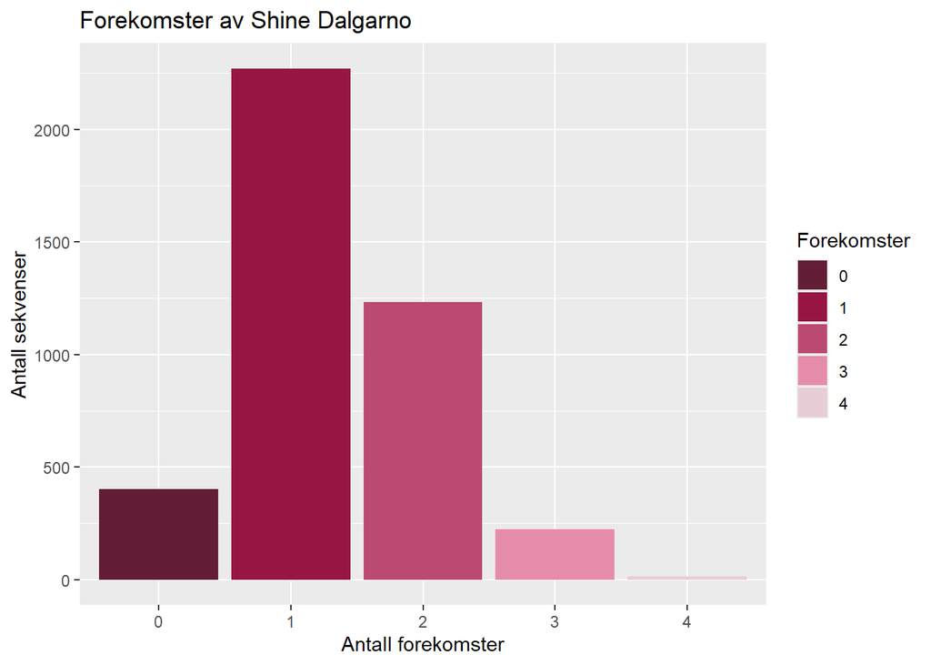

```r
# plot frekvenstabellen som et stolpediagram

ggplot(SD.frekvens, aes(x = Forekomster, y = Antall_sekvenser, fill = Forekomster)) +
  geom_col() +
  labs(x = 'Antall forekomster', y = 'Antall sekvenser', title = 'Forekomster av Shine Dalgarno') +
  scale_fill_manual(values = c('#631d36', '#961542', '#ba4a72', '#e68cab', '#e8ccd6'))
```